# Welcome to the ESM Item Repository Shiny app!

<sub><sup>30-1-2024 YKK + BK</sup></sub>

**What**

We are an open science initiative dedicated to fostering the advancement of Experience Sampling Methods (ESM) research. Launched in 2018 as part of a three-phase project, our repository now boasts 900+ items contributed by five research groups spanning six countries. Our goal is to provide researchers with a centralized source for discovering, learning about, and identifying relevant ESM items. Whether you’re looking to integrate existing knowledge, identify overlapping items, or support the conceptual development of new items, our repository is here to facilitate your research journey. Explore our [website](https://www.esmitemrepositoryinfo.com/) for more information on using the ESM Item Repository or contributing items.

**Why**

Exploring psychological phenomena in real-life settings is on the rise, driven by advances in ESM. However, the lack of standardized testing for ESM items introduces challenges, leading to diverse development practices and limited transparency.

Our initiative, the ESM Item Repository, addresses this gap. We aim to establish a centralized platform for ESM items, promoting transparency and reproducibility in psychological research.

Key Objectives:

- Centralized Source: Provide researchers with a unified platform to discover and understand ESM items.
- Collaboration: Facilitate the integration of existing knowledge, fostering a collaborative research environment.
- Overlap Identification: Assist researchers in identifying overlaps between items, enhancing measurement consistency.
- Development Support: Support the conceptual development and rigorous evaluation of ESM items.

**Do you want to contribute to the item repository?**

If you want to contribute items to the ESM repository, all you have to do is to follow these steps:

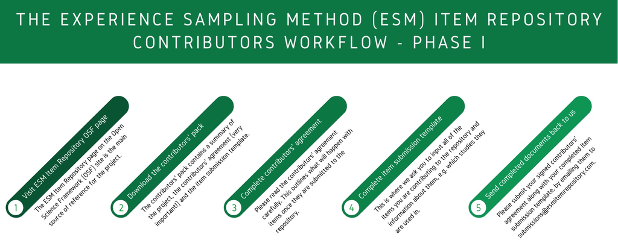

**How the app works**

The data resides in a .csv file hosted on “osf.io” and is made accessible to users through this Shiny app, enabling the search functionality for ESM items. Developed in R, the app leverages packages such as shiny, shinydashboard, shinyjs, and xlsx. It is deployed via “shinyapps.io” for convenient accessibility.

**Key Features**

Current version: 1.1.9

The items from the repository can be searched and selected by one the following attributes:

- Item ID
- Wording in original language
- English wording
- Item description
- Data set of origin
- Number of beeps per day of the study
- Measured population
- Citation of the study
- Existing reference
- Contributor’s contact information

Once selected, the data set with the items and relevant information can be downloaded either as a .csv file or as Excel file.

**Issues**

In case you run into any problems with the Shiny app, please let us know on our [GitHub issue tracker](https://github.com/ykkunkels/ESIR_portal/issues) or via the [contact form](https://esmitemrepositoryinfo.com/contact) on our website.

**Acknowledgements and citation help**

When insights and content from the repository are used, the repository should be cited as: Kirtley, O. J., Hiekkaranta, A. P., Kunkels, Y. K., Verhoeven, D., Van Nierop, M., & Myin-Germeys, I. (2019, April 2). The Experience Sampling Method (ESM) Item Repository. Retrieved from osf.io/kg376, DOI 10.17605/OSF.IO/KG376.

Funding acknowledgements: Olivia Kirtley and Anu Hiekkaranta’s work on the project is supported by postdoctoral and PhD fellowships, respectively, from an FWO Odysseus grant to Inez Myin-Germeys (FWO GOF8416N). Yoram Kunkels’ work on this project is supported by the European Research Council (ERC-CoG-2015; TRANS-ID; No 681466 to Marieke Wichers).

**Disclaimer**

We do not take responsibility for the quality of items within the repository. Inclusion of items within the repository does not indicate our endorsement of them. All items within the repository are subject to a Creative Commons Attribution Non-Commerical License (CC BY-NC).